# Deriving reproducible biomarkers from multi-site resting-state data: An Autism-based example - ScienceDirect

### 2.2. Step 1: Region definition

To reduce the dimensionality of the estimated connectomes, and to improve the interpretability of results, connectome nodes were defined from regions of interest (ROIs) rather than single voxels. ROIs can be either selected from a priori atlases or directly estimated from the correlation structure of the data being analyzed. Several choices for both approaches were used and compared to evaluate the impact of ROI definition on prediction accuracy. Note that the ROI were all defined on the training set to avoid possible overfitting.

We considered the following predefined atlases: Harvard Oxford (Desikan et al., 2006), a structural atlas computed from 36 individuals’ T1 images, Yeo (Yeo et al., 2011), a functional atlas composed of 17 networks derived from clustering (Lashkari et al., 2010) of functional connectivity on a thousand individuals, and Craddock (Craddock et al., 2012), a multiscale functional atlas computed using constrained spectral clustering, to study the impact of the number of regions.

We derived data-driven atlases based on four strategies. We explored two clustering methods: K-Means, a technique to cluster fMRI time series (Goutte et al., 1999, Thirion et al.,), which is a top-down approach minimizing cluster-level variance; and Ward's clustering, which also minimizes a variance criterion using hierarchical agglomeration. Ward's algorithm admits spatial constraints at no cost and has been extensively used to learn brain parcellations (Thirion et al.,). We also explored two decomposition methods: [Independent component analysis](https://www.sciencedirect.com/topics/medicine-and-dentistry/independent-component-analysis) (ICA) and multi-subject dictionary learning (MSDL). ICA is a widely-used method for extracting brain maps from R-fMRI (Calhoun et al., 2001, Beckmann and Smith, 2004) that maximizes the statistical independence between spatial maps. We specifically used the ICA implementation of Varoquaux et al. (2010). MSDL extracts a group atlas based on dictionary learning and multi-subject modeling, and employs spatial penalization to promote contiguous regions (Abraham et al., 2013). Unlike MSDL and Ward clustering, ICA and K-Means do not take into account the spatial structure of the features and are not able to enforce a particular spatial constraint on their components. We indirectly provide such structure by applying a Gaussian smoothing on the data (Thirion et al.,) with a full-width half maximum varying from 4 mm to 12 mm. Differences in the number of ROIs in the various atlases present a potential confound for our comparisons. As such, connectomes were constructed using only the 84 largest ROIs from each atlas, following (Abraham et al., 2013).<sup>3</sup>

### 2.3. Step 2: Time-series extraction

The common procedure to extract one representative time series per ROI is to take the average of the voxel signals in each region (for non overlapping ROIs) or the weighted average of non-overlapping regions (for fuzzy maps). For example, ICA and MSDL produce overlapping fuzzy maps. Each voxel's intensity reflects the level of confidence that this voxel belongs to a specific region in the atlas. In this case, we found that extracting time courses using a [spatial regression](https://www.sciencedirect.com/topics/medicine-and-dentistry/spatial-regression) that models each volume of R-fMRI data as a mixture of spatial patterns gives better results (details in Appendix A and Fig. D3 For non-overlapping ROIs, this procedure is equivalent to weighted averaging on the ROI maps.

After this extraction, we remove at the region level the same nuisance regressors as at the voxel level in the preprocessing. Signals summarizing high-variance voxels (CompCor (Behzadi et al., 2007)) are regressed out: the 5 first principal components of the 2% voxels with highest variance. In addition, we extract the signals of ROIs corresponding to physiological or acquisition noise<sup>4</sup> and regress them out to reject non-neural information (Varoquaux and Craddock, 2013). Finally, we also regress out primary and secondary head motion artifacts using 24-regressors derived from the parameters estimated during motion realignment (Friston et al., 1995).

### 2.4. Step 3: Connectivity matrix estimation

Since scans in the ABIDE dataset do not include enough R-fMRI time points to reliably estimate the true covariance matrix for a given individual, we used the Ledoit-Wolf shrinkage estimator, a parameter-free regularized covariance estimator (Ledoit and Wolf, 2004), to estimate relationships between ROI time series (details are given in Appendix B). For pipeline step 3, we studied three different connectivity measures to capture interactions between brain regions: (i) the correlation itself, (ii) partial correlations from the inverse covariance matrix (Varoquaux and Craddock, 2013, Smith et al., 2011), and (iii) the tangent embedding parameterization of the covariance matrix (Varoquaux et al., 2010, Ng et al., 2011). We obtained one connectivity weight per pair of regions for each subject. At the group level, we ran a nuisance regression across the connectivity coefficients to remove the effects of site, age and gender.

### 2.5. Step 4: Supervised learning

As ABIDE represents a post-hoc aggregation of data from several different sites, the assessments used to measure [autism](https://www.sciencedirect.com/topics/medicine-and-dentistry/pervasive-developmental-disorder) severity vary somewhat across sites. As a consequence, autism severity scores are not directly quantitatively comparable between sites. However, the diagnosis between [ASD](https://www.sciencedirect.com/topics/medicine-and-dentistry/atrial-septal-defect) and Typical Control (TC) is more reliable and has already been used in the context of classification (Nielsen et al., 2013; Plitt et al.,, Chen et al., 2011).

Discriminating between ASD and TC individuals is a supervised-learning task. We use the connectivity measures between all pairs of regions, extracted in the previous step, as features to train a classifier across individuals to discriminate ASD patients from TC.

We explore different machine-learning methods<sup>5</sup>. We first rely on the most commonly used approach, the ℓ<sub>2</sub>-penalized support vector classification SVC. Given that we expect only a few connections to be important for diagnosis, we also include the ℓ<sub>1</sub>-penalized sparse SVC. Finally, we include ridge regression, which also uses an ℓ<sub>2</sub> penality but is faster than the SVC. For all models we use the implementation of the scikit-learn library (Pedregosa et al., 2011)<sup>6</sup>. We chose to work only with linear models for their interpretability. In particular, in Subsection Section 3.7 we inspect classifier weights to identify which connections are the most important for prediction.

### 2.7. Experiments: Prediction on heterogeneous data

ABIDE datasets come from 17 international sites with no prior coordination, which is a typical clinical application setting. In this setting, we want to: (i) measure the performance of different prediction pipelines, (ii) use these measures to find the best options for each pipeline step (Fig. 1) and, (iii) extract ASD biomarkers from the best pipeline.

*Cross*-*validation*. In order to measure the prediction accuracy of a pipeline, we use 10-fold cross-validation by training it exclusively on training data (including atlas estimation) and predicting on the testing set. Any hyper-parameter of the various methods used inside a pipeline is set internally in a nested cross-validation.

We used two validation approaches. Inter-site prediction addresses the challenges associated with aggregate datasets by using whole sites as testing sets. This scenario also closely simulates the real world clinical challenge of not being able to sample data from every possible site. Note that this cross-validation can only be applied on a dataset with at least 10 acquisition sites, in order to leave out a different site in each fold. We do not apply it on subsample #5 that has been restricted to 3 sites to reduce site-specific variability. Intra-site prediction builds training and testing sets are as homogeneous as possible, reducing site-related variability. It is based on stratified shuffle split cross-validation, which splits participants into training and test sets while preserving the ratio of samples for each site and condition. We used 80% of the dataset for training and the remaining for testing.

*Learning curves*. A learning curve measures the impact of the number of training samples on the performance of a predictive model. For a given prediction task, the learning curve is constructed by varying the number of samples in the training set with a constant test set. Typically, an increasing curve indicates that the model can still gain additional useful information from more data. It is expected that the performance of a model will plateau at some point.

*Summarizing prediction scores for a pipeline choice*. To quantify the impact of the different options on the prediction accuracy, we select representative prediction scores for each model. Indeed, for ICA, K-Means, and MSDL, we explore several values for each parameters and thus obtain a range of prediction values. For these methods, we use the 10% best-performing pipelines for [post-hoc analysis](https://www.sciencedirect.com/topics/medicine-and-dentistry/post-hoc-analysis).<sup>8</sup> We do not rely only on the top-performing pipelines, as they may result from overfitting, nor the complete set of pipelines as some pipelines yield bad scores because of bad parametrization and may artificially lower the performance of these methods.

*Impact of pipeline choices on prediction accuracy*. In order to determine the best pipeline option at each step, we want to measure the impact of these choices on the prediction scores. In a full-factorial ANOVA, we then fit a linear model to explain prediction accuracy from the choice of pipeline steps, modeled as categorical variables. We report the corresponding effect size and its 95% confidence interval.

*Pairwise comparison of pipeline choice*. Two options can also be compared by comparing the scores between pairs of pipelines that differ only by that option using a [Wilcoxon test](https://www.sciencedirect.com/topics/medicine-and-dentistry/rank-sum-test) that does not rely on Gaussian assumptions.

*Extracting biomarkers*. For a given pipeline, the final classifier yields a biomarker to diagnose between HC and ASD. To characterize this biomarker, we measure *p*-values on the classifier weights. We obtain the null distribution of the weights by permuting the prediction labels.

### 2.8. Computational aspects

For data-driven brain atlas models (e.g. ICA), region-extraction methods entail feature learning on up to 300 GB of data, too big to fit in memory. Systematic study requires many cross-validations and subsamples and thus careful computational optimizations. Hence, for K-Means and ICA, we reduced the length of the time series by applying PCA dimensionality reduction with efficient randomized SVD (Martinsson et al., 2011). MSDL uses algorithmic optimizations (Abraham et al., 2013) to process a large number of subjects in a reasonable time<sup>9</sup> (2 hours for 871 subjects). However, it is still the most costly method because of the number of runs required to find the optimal value for its 3 parameters.

For reproducibility, we rely on the publicly available implementations of the scikit-learn package (Pedregosa et al., 2011) for all the clustering algorithms, connectivity matrix estimators and predictors.

## 3. Results

Here we present the most notable trends emerging from our analyses. More details are provided in supplementary materials. First, we compared inter- and intra-site prediction of [ASD](https://www.sciencedirect.com/topics/medicine-and-dentistry/atrial-septal-defect) diagnostic labels while varying the number of subjects in the training set. Second, in a [post-hoc analysis](https://www.sciencedirect.com/topics/medicine-and-dentistry/post-hoc-analysis), we identified the pipeline choices most relevant for prediction and proposed a good choice of pipeline steps for prediction. Finally, by analyzing the weights of the classifiers, we highlighted functional connections that best discriminate between ASD and TC.

### 3.1. Overall prediction results

[figure not shown]

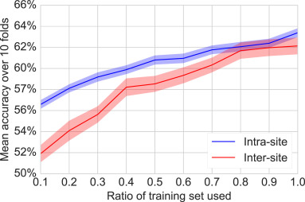

Fig. 2. *Learning curve.* Classification results obtained by varying the ratio of the training set using to train the classifier while keeping a fixed testing set. The colored bands represent the standard error of the prediction. A score increasing with the number of subjects, i. e. a positive slope indicates that the addition of new subjects improves performance. This curve is an average of the results obtained on several subsamples. Detailed results per subsamples are presented in the appendices –Fig. Fig. D6.

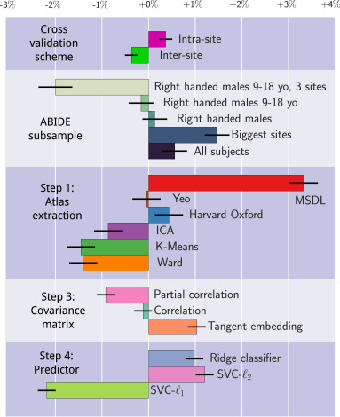

Fig. 3. *Impact of pipeline steps on prediction*. Each block of bars represents a step of the pipeline (namely step 1, 3 and 4). We also prepended two steps corresponding to the cross-validation schemes and ABIDE subsamples. Each bar represents the impact of the corresponding option on the prediction accuracy, relative to the mean prediction. This effect is measured via a full-factorial analysis of variance (ANOVA), analyzing the contribution of each step in a linear model. Each step of the pipeline is considered as a categorical variable. Error bars give the 95% confidence interval. Multi Subject Dictionary Learning (MSDL) atlas extraction method gives significantly better results while reference atlases are slightly better than the mean. Among all matrix types, tangent embedding is the best on all ABIDE subsets. Finally, *l*<sub>2</sub>-regularized classifiers perform better than *l*<sub>1</sub>-regularized ones. Results for each subsamples are presented in the appendices –Fig. Fig. D8.

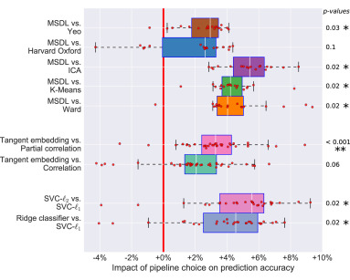

Fig. 4. *Comparison of pipeline options.* Each plot compares the classification accuracy scores if one parameter is changed and the others kept fixed. We measured statistical signficance using a [Wilcoxon signed rank test](https://www.sciencedirect.com/topics/medicine-and-dentistry/wilcoxon-signed-ranks-test) and corrected for multiple comparisons. Detailed one-to-one comparison of the scores are shown in the appendices–Fig. Fig. D5.